# FINAL PROJECT: 'Predicting MLB Player Salaries: A Data-Driven Approach'

## Major League Baseball's Most Cost-Effective variables

### 1. Background and Context

In Major League Baseball (MLB), determining a player's salary is a critical decision-making process for team managers and owners. Salaries are influenced by a variety of factors, including individual player performance, team success, and market trends.

### 2. Problem Statement

As MLB teams seek to optimize their budget allocation, the ability to accurately predict player salaries based on performance metrics becomes increasingly valuable. The objective of this notebook is to develop a machine learning model capable of predicting MLB player salaries using key performance metrics.

### 3. About this Dataset

This dataset contains MLB hitting statistics from the 1985 through 2016 seasons. The dataset allows us to see which players were the most cost-effective in terms of salary and production.

There are several ways to measure a player's cost-effectiveness, but one simple method is to compare their salary to their production (measured by runs created). Players who create a lot of runs while being paid relatively little are more cost-effective than players who are paid more but produce less.

#### Columns

File: MLB_stats.csv | Column Name | Description | Data Type | |---------------|--------------------------------------------------------|-----------| | Player Name | The player's name. | String | | weight | The player's weight in pounds. | Numeric | | height | The player's height in inches. | Numeric | | bats | The player's batting handedness. | String | | throws | The player's throwing handedness. | String | | Season | The season in which the statistics were accrued. | String | | League | The league in which the player played. | String | | Team | The team for which the player played. | String | | Franchise | The franchise to which the team belongs. | String | | G | The number of games the player played. | Numeric | | AB | The number of at-bats the player had. | Numeric | | R | The number of runs the player scored. | Numeric | | H | The number of hits the player had. | Numeric | | 2B | The number of doubles the player hit. | Numeric | | 3B | The number of triples the player hit. | Numeric | | HR | The number of home runs the player hit. | Numeric | | RBI | The number of runs batted in the player had. | Numeric | | SB | The number of bases the player stole. | Numeric | | BB | The number of bases on balls the player drew. | Numeric | | SO | The number of strikeouts the player had. | Numeric | | salary | The player's salary in dollars. | Numeric | | IBB | The number of intentional walks the player received. | Numeric | | HBP | The number of times the player was hit by a pitch. | Numeric | | SH | The number of times the player sacrifice bunted. | Numeric | | SF | The number of times the player hit a sacrifice fly. | Numeric | | PA | The number of plate appearances the player had. | Numeric |

### 4. Metrics and Assumptions

#### Metrics:

For this project, the primary metrics used to evaluate the model’s performance are:

- **Mean Squared Error (MSE)**: Measures the average squared difference between predicted and actual salaries.
- **Root Mean Squared Error (RMSE)**: Provides a more interpretable measure of error in the same units as salary (USD).
- **R-squared (R²)**: Measures how much variance in salary is explained by the model.

### 5. Approach and Process

The approach can be summarized in several steps:

#### 5.1. Data Collection and Preparation

The dataset consists of historical player salary data and corresponding performance metrics. Key variables include:

- **Cost_game**: Cost per game played.
- **Cost_TB**: Cost per total bases.
- **Season**: The season year.
- **RC**: Runs Created (a metric for player contribution).
- **RE**: Run Efficiency.

The data was cleaned and prepared for analysis, ensuring no missing values and that the performance metrics were standardized.

#### 5.2. Model Selection

After evaluating several machine learning models (including Linear Regression, Ridge, Lasso, and Gradient Boosting), **Random Forest** was selected as the preferred model for its balance of accuracy and interpretability. Random Forests are particularly effective because they reduce overfitting by averaging multiple decision trees, thus producing robust predictions.

#### 5.3. Model Training

The Random Forest model was trained using the following features:

- **Cost per Game**
- **Cost per Total Bases**
- **Season**
- **Runs Created**
- **Run Efficiency**

## Load Data

```python
import pandas as pd
import matplotlib.pyplot as plt
%matplotlib inline
```

```python
import os
# Load the dataset to inspect the data
mlb = pd.read_csv('https://raw.git.generalassemb.ly/elyse-dargenio/DSS-722-Project-Submission/milla-init/MLB_stats.csv/MLB_stats.csv?token=AAANB57T6FAIBJ2UKQ2ZUY3HBSYUK')

# Display the first few rows to understand the structure
mlb.head()
```

|  | index | playerID | Player Name | weight | height | bats | throws | Season | League | teamID | ... | RBI | SB | BB | SO | salary | IBB | HBP | SH | SF | PA |
| --- | --- | --- | --- | --- | --- | --- | --- | --- | --- | --- | --- | --- | --- | --- | --- | --- | --- | --- | --- | --- | --- |
| 0 | 0 | aardsda01 | David Aardsma | 215 | 75 | R | R | 2004 | NL | SFN | ... | 0 | 0 | 0 | 0 | 300000 | 0 | 0 | 0 | 0 | 0 |
| 1 | 1 | aardsda01 | David Aardsma | 215 | 75 | R | R | 2007 | AL | CHA | ... | 0 | 0 | 0 | 0 | 387500 | 0 | 0 | 0 | 0 | 0 |
| 2 | 2 | aardsda01 | David Aardsma | 215 | 75 | R | R | 2008 | AL | BOS | ... | 0 | 0 | 0 | 1 | 403250 | 0 | 0 | 0 | 0 | 1 |
| 3 | 3 | aardsda01 | David Aardsma | 215 | 75 | R | R | 2009 | AL | SEA | ... | 0 | 0 | 0 | 0 | 419000 | 0 | 0 | 0 | 0 | 0 |
| 4 | 4 | aardsda01 | David Aardsma | 215 | 75 | R | R | 2012 | AL | NYA | ... | 0 | 0 | 0 | 0 | 500000 | 0 | 0 | 0 | 0 | 0 |

5 rows × 29 columns

## Data Preprocessing

```python
# Checking for missing values and printing the general info of the dataset
missing_values = mlb.isnull().sum()
mlb_info = mlb.info()

# Print the missing values summary
missing_values
```

```
<class 'pandas.core.frame.DataFrame'>
RangeIndex: 28293 entries, 0 to 28292
Data columns (total 29 columns):
 #   Column       Non-Null Count  Dtype
---  ------       --------------  -----
 0   index        28293 non-null  int64
 1   playerID     28293 non-null  object
 2   Player Name  28293 non-null  object
 3   weight       28293 non-null  int64
 4   height       28293 non-null  int64
 5   bats         28293 non-null  object
 6   throws       28293 non-null  object
 7   Season       28293 non-null  int64
 8   League       28293 non-null  object
 9   teamID       28293 non-null  object
```

[output cut: 21 more lines]

```
index          0
playerID       0
Player Name    0
weight         0
height         0
bats           0
throws         0
Season         0
League         0
teamID         0
Team           0
Franchise      0
G              0
AB             0
R              0
H              0
2B             0
3B             0
HR             0
RBI            0
SB             0
BB             0
SO             0
salary         0
IBB            0
HBP            0
SH             0
SF             0
PA             0
dtype: int64
```

```python
# Dropping the 'index' column so we can check for duplicated rows
mlb_cleaned = mlb.drop(columns=['index'])

# Checking for duplicated rows
duplicates = mlb_cleaned.duplicated().sum()

# Dropping duplicated rows if any
mlb_cleaned = mlb_cleaned.drop_duplicates()

mlb = mlb_cleaned

duplicates
```

```
21
```

```python
mlb.shape
```

```
(28272, 28)
```

```python
mlb.nunique()
```

```
playerID       5005
Player Name    4931
weight          107
height           18
bats              3
throws            2
Season           32
League            2
teamID           35
Team             35
Franchise        30
G               163
AB              695
R               146
H               231
2B               59
3B               23
HR               64
RBI             157
SB               80
BB              147
SO              205
salary         3352
IBB              43
HBP              33
SH               29
SF               18
PA              770
dtype: int64
```

### Dataset Overview:

- **Number of Rows**: 28,272
- **Number of Columns**: 28
- **Missing Values**: None
- **Duplicated Rows**: 21
- **Unique Players**: 5,005 (based on `playerID`)
- **'Bats' Categories**:
  - Left (L)
  - Right (R)
  - Both (B)
- **Seasons Covered**: 32

### Clean Data

```python
# Checking for unique values in the 'Team' and 'Franchise' columns to find the difference
team = mlb_cleaned['Team'].unique()
franchise = mlb_cleaned['Franchise'].unique()

team, franchise
```

```
(array(['San Francisco Giants', 'Chicago White Sox', 'Boston Red Sox',
        'Seattle Mariners', 'New York Yankees', 'New York Mets',
        'Baltimore Orioles', 'Cincinnati Reds', 'Houston Astros',
        'Oakland Athletics', 'Minnesota Twins', 'Florida Marlins',
        'California Angels', 'Milwaukee Brewers', 'Atlanta Braves',
        'Colorado Rockies', 'Philadelphia Phillies',
        'Tampa Bay Devil Rays', 'Kansas City Royals', 'San Diego Padres',
        'Los Angeles Angels of Anaheim', 'Los Angeles Dodgers',
        'Arizona Diamondbacks', 'Toronto Blue Jays', 'St. Louis Cardinals',
        'Detroit Tigers', 'Cleveland Indians', 'Texas Rangers',
        'Chicago Cubs', 'Montreal Expos', 'Anaheim Angels',
        'Tampa Bay Rays', 'Pittsburgh Pirates', 'Miami Marlins',
        'Washington Nationals'], dtype=object),
 array(['San Francisco Giants', 'Chicago White Sox', 'Boston Red Sox',
        'Seattle Mariners', 'New York Yankees', 'New York Mets',
        'Baltimore Orioles', 'Cincinnati Reds', 'Houston Astros',
        'Oakland Athletics', 'Minnesota Twins', 'Florida Marlins',
        'Los Angeles Angels of Anaheim', 'Milwaukee Brewers',
        'Atlanta Braves', 'Colorado Rockies', 'Philadelphia Phillies',
        'Tampa Bay Rays', 'Kansas City Royals', 'San Diego Padres',
        'Los Angeles Dodgers', 'Arizona Diamondbacks', 'Toronto Blue Jays',
        'St. Louis Cardinals', 'Detroit Tigers', 'Cleveland Indians',
        'Texas Rangers', 'Chicago Cubs', 'Washington Nationals',
        'Pittsburgh Pirates'], dtype=object))
```

```python
team_to_franchise = {'California Angels': 'Los Angeles Angels of Anaheim',
                     'Anaheim Angels': 'Los Angeles Angels of Anaheim',
                     'Montreal Expos': 'Washington Nationals',
                     'Tampa Bay Devil Rays': 'Tampa Bay Rays',
                     'Miami Marlins': 'Florida Marlins'
                    }

# Applying the mapping to the 'Team' column to standardize names
mlb_cleaned['Team'] = mlb_cleaned['Team'].replace(team_to_franchise)


mlb = mlb_cleaned
mlb.nunique()
```

```
playerID       5005
Player Name    4931
weight          107
height           18
bats              3
throws            2
Season           32
League            2
teamID           35
Team             30
Franchise        30
G               163
AB              695
R               146
H               231
2B               59
3B               23
HR               64
RBI             157
SB               80
BB              147
SO              205
salary         3352
IBB              43
HBP              33
SH               29
SF               18
PA              770
dtype: int64
```

```python
# Checking for differences between 'playerID' and 'Player Name'
player_id_difference = mlb_cleaned[['playerID', 'Player Name']].drop_duplicates()

# Display any differences if found
player_id_difference[player_id_difference.duplicated]
```

|  | playerID | Player Name |
| --- | --- | --- |

There are no differences between 'playerID' and 'Player Name' columns; each 'playerID' corresponds uniquely to a specific player name.

```python
# Let's find the max and min values for specific columns
columns = ['G', 'AB', 'PA']

max_values = mlb[columns].max()
min_values = mlb[columns].min()

print("Max Values:")
print(max_values)

print("\nMin Values:")
print(min_values)
```

```
Max Values:
G     163
AB    716
PA    783
dtype: int64

Min Values:
G     1
AB    0
PA    0
dtype: int64
```

```python
# Let's find the mean, median, and mode for those columns
mean_values = mlb[columns].mean()
median_values = mlb[columns].median()
mode_values = mlb[columns].mode().iloc[0]

print("Mean Values:")
print(mean_values)

print("\nMedian Values:")
print(median_values)

print("\nMode Values:")
print(mode_values)
```

```
Mean Values:
G      63.960173
AB    161.964912
PA    183.457201
dtype: float64

Median Values:
G     50.0
AB    57.0
PA    66.0
dtype: float64

Mode Values:
G     33
AB     0
PA     0
Name: 0, dtype: int64
```

```python
mlb['PA'].describe()
```

```
count    28272.000000
mean       183.457201
std        226.259067
min          0.000000
25%          1.000000
50%         66.000000
75%        337.000000
max        783.000000
Name: PA, dtype: float64
```

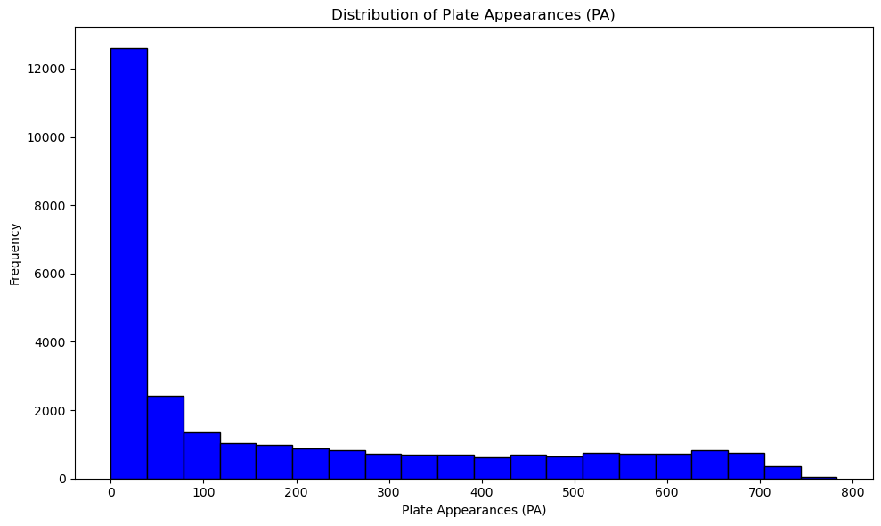

```python
plt.figure(figsize=(10,6))
plt.hist(mlb['PA'], bins=20, color='blue', edgecolor='black')
plt.title('Distribution of Plate Appearances (PA)')
plt.xlabel('Plate Appearances (PA)')
plt.ylabel('Frequency')
plt.tight_layout()
plt.show()
```

```python
# Removing rows where 'PA' is less than 99 for a better distribution
mlb_cleaned = mlb[mlb['PA'] >= 100]
mlb_cleaned.info()
```

```
<class 'pandas.core.frame.DataFrame'>
Index: 12400 entries, 17 to 28290
Data columns (total 28 columns):
 #   Column       Non-Null Count  Dtype
---  ------       --------------  -----
 0   playerID     12400 non-null  object
 1   Player Name  12400 non-null  object
 2   weight       12400 non-null  int64
 3   height       12400 non-null  int64
 4   bats         12400 non-null  object
 5   throws       12400 non-null  object
 6   Season       12400 non-null  int64
 7   League       12400 non-null  object
 8   teamID       12400 non-null  object
 9   Team         12400 non-null  object
```

[output cut: 20 more lines]

```python
mlb = mlb_cleaned
mlb['PA'].describe()
```

```
count    12400.000000
mean       395.343790
std        189.168494
min        100.000000
25%        222.000000
50%        384.000000
75%        566.000000
max        783.000000
Name: PA, dtype: float64
```

### Cost per Stats

```python
# Creating new columns for Cost per Stat
mlb['Cost_HR'] = mlb['salary'] / mlb['HR'].replace(0,1) # Preventing division by 0
mlb['Cost_RBI'] = mlb['salary'] / mlb['RBI'].replace(0,1)
mlb['Cost_game'] = mlb['salary'] / mlb['G'].replace(0,1)
mlb['Cost_PA'] = mlb['salary'] / mlb['PA'].replace(0,1)

mlb[['Cost_HR', 'Cost_RBI', 'Cost_game', 'Cost_PA']].head()
```

|  | Cost_HR | Cost_RBI | Cost_game | Cost_PA |
| --- | --- | --- | --- | --- |
| 17 | 14583.333333 | 4268.292683 | 1966.292135 | 670.498084 |
| 19 | 85000.000000 | 8793.103448 | 3187.500000 | 1053.719008 |
| 32 | 12111.111111 | 3303.030303 | 1079.207921 | 293.010753 |
| 33 | 7000.000000 | 1983.333333 | 991.666667 | 252.118644 |
| 34 | 31250.000000 | 7575.757576 | 2293.577982 | 714.285714 |

Summary of the new columns:

- **Cost_HR**: Salary divided by the number of home runs.
- **Cost_RBI**: Salary divided by runs batted in.
- **Cost_game**: Salary divided by games played.
- **Cost_PA**: Salary divided by plate appearances.

### Efficiency Metrics

```python
# Create a new variable: 'Total_H'
mlb['Total_H'] = mlb['H'] + mlb['2B'] + mlb['3B'] + mlb['HR']

# Create Batting Average (BA)
mlb['BA'] = mlb['Total_H'] / mlb['PA']

# Create On-Base Percentage (OBP)
mlb['OBP'] = (mlb['Total_H'] + mlb['BB'] + mlb['HBP']) / (mlb['PA'] + mlb['SF'])

# Create Slugging Percentage (SLG)
mlb['SLG'] = (mlb['H'] + 2 * mlb['2B'] + 3 * mlb['3B'] + 4 * mlb['HR']) / mlb['PA']

mlb[['BA', 'OBP', 'SLG']].head()
```

|  | BA | OBP | SLG |
| --- | --- | --- | --- |
| 17 | 0.363985 | 0.390977 | 0.563218 |
| 19 | 0.322314 | 0.415638 | 0.429752 |
| 32 | 0.309140 | 0.363636 | 0.443548 |
| 33 | 0.315678 | 0.398323 | 0.491525 |
| 34 | 0.325714 | 0.397143 | 0.485714 |

### Composite Metrics

```python
# Create Total Bases (TB)
mlb['TB'] = mlb['H'] + 2 * mlb['2B'] + 3 * mlb['3B'] + 4 * mlb['HR']

# Create Runs Created (RC)
mlb['RC'] = ((mlb['Total_H'] + mlb['BB']) * mlb['TB']) / (mlb['PA'] + mlb['BB'])

# Create Runs Efficiency (RE)
mlb['RE'] = (mlb['RC'] + mlb['R'] + mlb['RBI']) / mlb['PA']

mlb[['TB', 'RC', 'RE']].head()
```

|  | TB | RC | RE |
| --- | --- | --- | --- |
| 17 | 147 | 56.622222 | 0.500468 |
| 19 | 104 | 39.148289 | 0.409704 |
| 32 | 165 | 55.708763 | 0.348679 |
| 33 | 232 | 84.488189 | 0.433238 |
| 34 | 170 | 62.150538 | 0.377573 |

```python
# Create Salary per Total Bases (S/TB)
mlb['Cost_TB'] = mlb['salary'] / mlb['TB'].replace(0,1)

# Create Salary per Runs Created (S/RC)
mlb['Cost_RC'] = mlb['salary'] / mlb['RC'].replace(0,1)


mlb[['Cost_TB', 'Cost_RC']].head()
```

|  | Cost_TB | Cost_RC |
| --- | --- | --- |
| 17 | 1190.476190 | 3090.659341 |
| 19 | 2451.923077 | 6513.694639 |
| 32 | 660.606061 | 1956.604210 |
| 33 | 512.931034 | 1408.480895 |
| 34 | 1470.588235 | 4022.491349 |

## Data Exploratory Analysis

### Summary Statistics

```python
summary_stats = mlb[['salary', 'PA', 'Season', 'RC', 'RE', 'BA', 'TB', 'OBP', 'SLG', 'Cost_HR', 'Cost_RBI', 'Cost_RC', 'Cost_TB', 'Cost_game', 'Cost_PA']]
summary_stats.describe()
```

|  | salary | PA | Season | RC | RE | BA | TB | OBP | SLG | Cost_HR | Cost_RBI | Cost_RC | Cost_TB | Cost_game | Cost_PA |
| --- | --- | --- | --- | --- | --- | --- | --- | --- | --- | --- | --- | --- | --- | --- | --- |
| count | 1.240000e+04 | 12400.000000 | 12400.000000 | 12400.000000 | 12400.000000 | 12400.000000 | 12400.000000 | 12400.000000 | 12400.000000 | 1.240000e+04 | 1.240000e+04 | 1.240000e+04 | 12400.000000 | 12400.000000 | 12400.000000 |
| mean | 2.551407e+06 | 395.343790 | 2000.724113 | 67.395242 | 0.386632 | 0.305029 | 178.758145 | 0.395767 | 0.433539 | 4.063446e+05 | 6.693472e+04 | 4.671259e+04 | 16135.731670 | 26110.972376 | 6853.621161 |
| std | 3.867925e+06 | 189.168494 | 9.011652 | 44.881171 | 0.099350 | 0.046712 | 104.344322 | 0.055517 | 0.090472 | 8.310561e+05 | 1.300891e+05 | 9.188156e+04 | 28127.888431 | 44996.830353 | 11372.396126 |
| min | 6.000000e+04 | 100.000000 | 1985.000000 | 2.144144 | 0.090400 | 0.105769 | 14.000000 | 0.142857 | 0.132075 | 1.479592e+03 | 6.144068e+02 | 3.924074e+02 | 170.588235 | 388.198758 | 86.206897 |
| 25% | 3.500000e+05 | 222.000000 | 1993.000000 | 30.026089 | 0.316972 | 0.275693 | 88.000000 | 0.360324 | 0.370854 | 5.300000e+04 | 9.909091e+03 | 6.909936e+03 | 2451.159732 | 3434.782609 | 1023.913411 |
| 50% | 8.000000e+05 | 384.000000 | 2001.000000 | 58.325614 | 0.379924 | 0.306695 | 164.000000 | 0.395883 | 0.432432 | 1.526389e+05 | 2.750000e+04 | 1.940785e+04 | 6771.870850 | 8787.522401 | 2755.771443 |
| 75% | 3.100000e+06 | 566.000000 | 2008.000000 | 96.817637 | 0.449810 | 0.336638 | 257.250000 | 0.431747 | 0.493760 | 4.125000e+05 | 7.287202e+04 | 5.055656e+04 | 18160.001276 | 29693.161232 | 7798.462041 |
| max | 3.300000e+07 | 783.000000 | 2016.000000 | 260.798054 | 0.832679 | 0.511811 | 528.000000 | 0.640514 | 0.825175 | 1.450000e+07 | 4.126628e+06 | 3.152500e+06 | 485000.000000 | 659090.909091 | 162857.136000 |

```python
import seaborn as sns
```

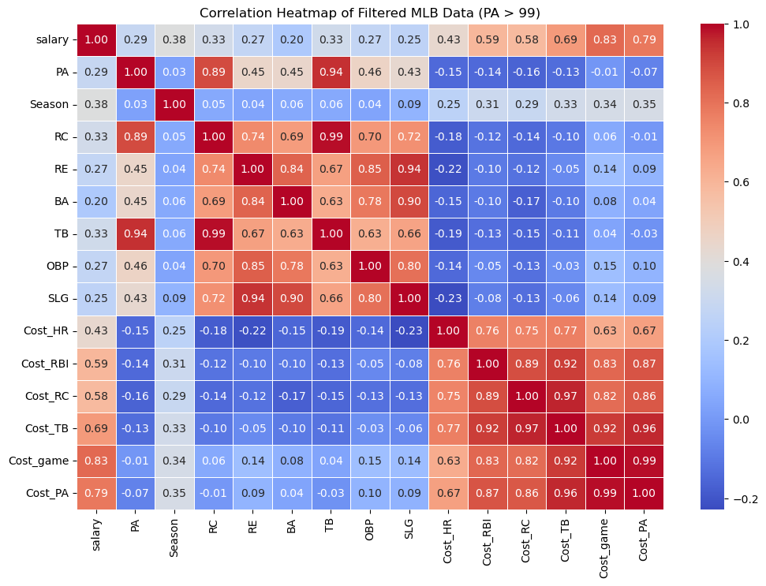

```python
# Generating a correlation heatmap for the 'summary_stats'
plt.figure(figsize=(12, 8))
correlation = summary_stats.corr()

sns.heatmap(correlation, annot=True, cmap="coolwarm", fmt='.2f', linewidths=0.5)
plt.title('Correlation Heatmap of Filtered MLB Data (PA > 99)')
plt.show()
```

```python
# Extracting the correlation of all variables with 'salary'
correlation_salary = summary_stats.corr()['salary'].sort_values(ascending=False)
correlation_salary
```

```
salary       1.000000
Cost_game    0.827196
Cost_PA      0.788518
Cost_TB      0.691182
Cost_RBI     0.592715
Cost_RC      0.579229
Cost_HR      0.434880
Season       0.384633
RC           0.332675
TB           0.325362
PA           0.285243
RE           0.271834
OBP          0.271085
SLG          0.253641
BA           0.196833
Name: salary, dtype: float64
```

```python
# Standardizing selected variables (BA, OBP, SLG, RC, PE) to try to find a better correlation using StandardScaler
from sklearn.preprocessing import StandardScaler

variables_stand = ['BA', 'OBP', 'SLG', 'RC', 'RE']

# Initializing the StandardScaler
scaler = StandardScaler()

# Applying the scaler to the selected variables
summary_stats[variables_stand] = scaler.fit_transform(summary_stats[variables_stand])

# Recalculating the correlation after standardization
correlation_salary_stand = summary_stats.corr()['salary'].sort_values(ascending=False)
correlation_salary_stand
```

[output not shown]

```
salary       1.000000
Cost_game    0.827196
Cost_PA      0.788518
Cost_TB      0.691182
Cost_RBI     0.592715
Cost_RC      0.579229
Cost_HR      0.434880
Season       0.384633
RC           0.332675
TB           0.325362
PA           0.285243
RE           0.271834
OBP          0.271085
SLG          0.253641
BA           0.196833
Name: salary, dtype: float64
```

```python
# Creating polynomial features for RC² and RE²
summary_stats.loc[:,'RC_squared'] = summary_stats['RC'] ** 2
summary_stats.loc[:,'RE_squared'] = summary_stats['RE'] ** 2

print(summary_stats[['RC_squared', 'RE_squared']].head())
```

```
    RC_squared  RE_squared
17    0.057621    1.312987
19    0.396141    0.053932
32    0.067807    0.145945
33    0.145058    0.220076
34    0.013657    0.008316
```

```python
# Let's run again the correlation to see if by creating polynomial feature for RC² and RE² helps better with the correlation with salary
correlation_salary = summary_stats.corr()['salary'].sort_values(ascending=False)
correlation_salary
```

```
salary        1.000000
Cost_game     0.827196
Cost_PA       0.788518
Cost_TB       0.691182
Cost_RBI      0.592715
Cost_RC       0.579229
Cost_HR       0.434880
Season        0.384633
RC            0.332675
TB            0.325362
PA            0.285243
RE            0.271834
OBP           0.271085
SLG           0.253641
RC_squared    0.198239
BA            0.196833
RE_squared    0.109138
Name: salary, dtype: float64
```

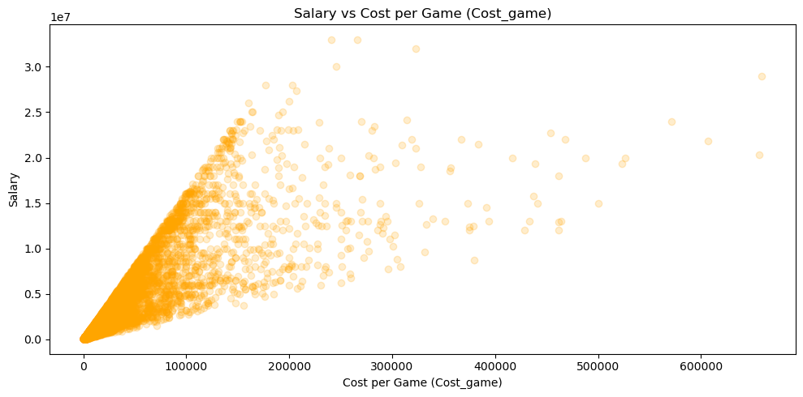

```python
# Plotting the relationship between Salary and Cost_game
plt.figure(figsize=(10, 5))
plt.scatter(summary_stats['Cost_game'], summary_stats['salary'], color='orange', alpha=0.2)
plt.title('Salary vs Cost per Game (Cost_game)')
plt.xlabel('Cost per Game (Cost_game)')
plt.ylabel('Salary')
plt.tight_layout()
plt.show()
```

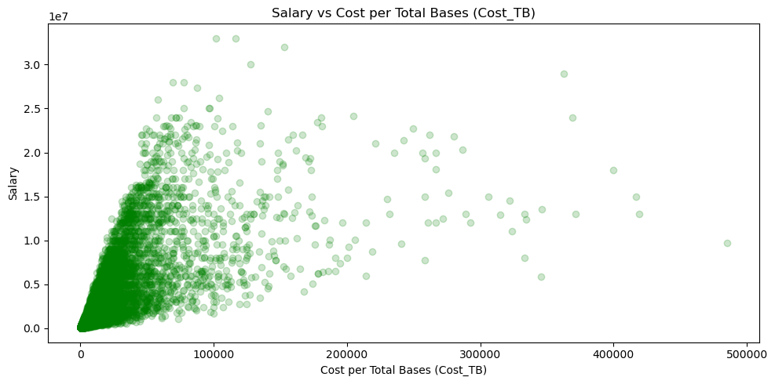

```python
# Plotting the relationship between Salary and Cost_TB
plt.figure(figsize=(10, 5))
plt.scatter(summary_stats['Cost_TB'], summary_stats['salary'], color='green', alpha=0.2)
plt.title('Salary vs Cost per Total Bases (Cost_TB)')
plt.xlabel('Cost per Total Bases (Cost_TB)')
plt.ylabel('Salary')
plt.tight_layout()
plt.show()
```

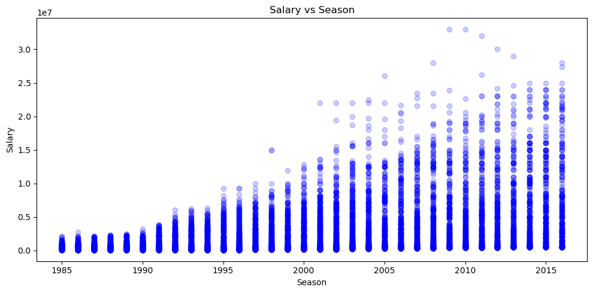

```python
# Plotting the relationship between Salary and Season
plt.figure(figsize=(10, 5))
plt.scatter(summary_stats['Season'], summary_stats['salary'], color='blue', alpha=0.2)
plt.title('Salary vs Season')
plt.xlabel('Season')
plt.ylabel('Salary')
plt.tight_layout()
plt.show()
```

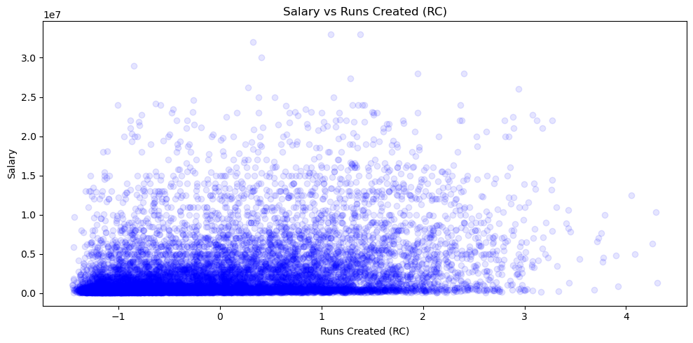

```python
# Plotting the relationship between Salary and RC
plt.figure(figsize=(10, 5))
plt.scatter(summary_stats['RC'], summary_stats['salary'], color='blue', alpha=0.1)
plt.title('Salary vs Runs Created (RC)')
plt.xlabel('Runs Created (RC)')
plt.ylabel('Salary')
plt.tight_layout()
plt.show()
```

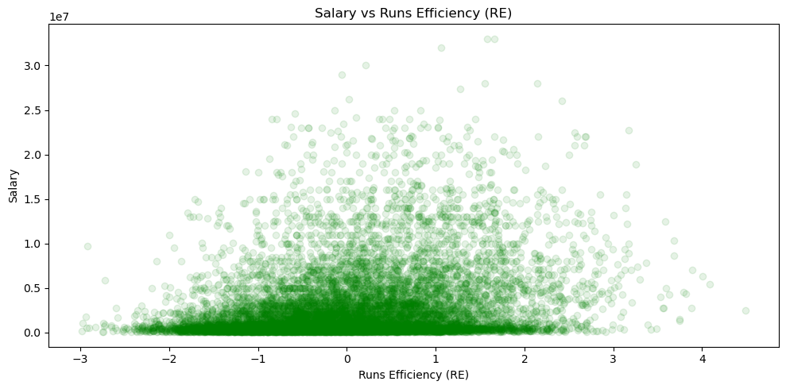

```python
# Plotting the relationship between Salary and Runs Efficiency (RE)
plt.figure(figsize=(10, 5))
plt.scatter(summary_stats['RE'], summary_stats['salary'], color='green', alpha=0.1)
plt.title('Salary vs Runs Efficiency (RE)')
plt.xlabel('Runs Efficiency (RE)')
plt.ylabel('Salary')
plt.tight_layout()
plt.show()
```

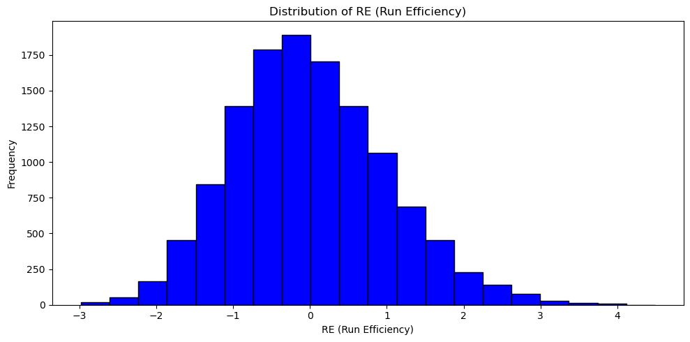

```python
# Visualizing the distribution of RE
plt.figure(figsize=(10, 5))
plt.hist(summary_stats['RE'], bins=20, color='blue', edgecolor='black')
plt.title('Distribution of RE (Run Efficiency)')
plt.xlabel('RE (Run Efficiency)')
plt.ylabel('Frequency')
plt.tight_layout()
plt.show()
```

## Train-Test Split

1. **Target variable (y)**: `'salary'`
2. **Feature Variables (X)**: `'Cost_game'`, `'Cost_TB'`, `'Season'`, `'RC'`, and `'RE'`
3. **Test Size**: 80% of the data for training and 20% for testing.
4. **Random Seed**: `random_state=42`

```python
mlb = summary_stats[['salary', 'Cost_game', 'Cost_TB', 'Season', 'RC', 'RE']]
mlb.info()
```

```
<class 'pandas.core.frame.DataFrame'>
Index: 12400 entries, 17 to 28290
Data columns (total 6 columns):
 #   Column     Non-Null Count  Dtype
---  ------     --------------  -----
 0   salary     12400 non-null  int64
 1   Cost_game  12400 non-null  float64
 2   Cost_TB    12400 non-null  float64
 3   Season     12400 non-null  int64
 4   RC         12400 non-null  float64
 5   RE         12400 non-null  float64
dtypes: float64(4), int64(2)
memory usage: 936.2 KB
```

```python
from sklearn.model_selection import train_test_split

# Defining the feature variables (X) and the target variable (y)
X = mlb[['Cost_game', 'Cost_TB', 'Season', 'RC', 'RE']]
y = mlb['salary']

# Splitting the data into training and testing sets (80% train, 20% test)
X_train, X_test, y_train, y_test = train_test_split(X, y, test_size=0.2, random_state=42)

# Display the size of the training and testing sets
print(f"Training set size: {X_train.shape[0]}")
print(f"Testing set size: {X_test.shape[0]}")
```

```
Training set size: 9920
Testing set size: 2480
```

### Cross-Validation: K-Fold Cross-Validation0

1. **Model**: Linear Regression
2. **K-Fold Cross-Validation**: We'll use K = 5 (folds) from Sklearn, meaning the data will be split into 5 subsets (folds). The model will be trained on 4 folds and tested on the remaining fold.
3. **Evaluate the Model**: Calculate the performance using Mean Squared Error (MSE) and R-squared (R²).

```python
y.var()
```

```
14960846999909.803
```

```python
from sklearn.model_selection import KFold, cross_val_score
from sklearn.linear_model import LinearRegression
from sklearn.metrics import mean_squared_error, r2_score
import numpy as np
from sklearn import metrics
```

```python
kf = KFold(n_splits=5, shuffle=True, random_state=42)
mse_values = []
scores = []
n = 0

print("~~~~ CROSS VALIDATION each fold ~~~~")
for train_index, test_index in kf.split(X, y):
    lr = LinearRegression().fit(X.iloc[train_index], y.iloc[train_index])

    mse_values.append(metrics.mean_squared_error(y.iloc[test_index], lr.predict(X.iloc[test_index])))
    scores.append(lr.score(X, y))

    n += 1

    print('Model {}'.format(n))
    print('MSE: {}'.format(mse_values[n-1]))
    print('R2: {}\n'.format(scores[n-1]))


print("~~~~ SUMMARY OF CROSS VALIDATION ~~~~")
print('Mean of MSE for all folds: {}'.format(np.mean(mse_values)))
print('Mean of R2 for all folds: {}'.format(np.mean(scores)))
```

```
~~~~ CROSS VALIDATION each fold ~~~~
Model 1
MSE: 3120777281736.5703
R2: 0.793365262746405

Model 2
MSE: 3112967918775.4727
R2: 0.7932448467860787

Model 3
MSE: 2633749146556.079
R2: 0.7932649791311908

Model 4
MSE: 3205829495935.671
R2: 0.793247459515656

Model 5
MSE: 3501817256973.9326
R2: 0.7931091025516924

~~~~ SUMMARY OF CROSS VALIDATION ~~~~
Mean of MSE for all folds: 3115028219995.5454
Mean of R2 for all folds: 0.7932463301462046
```

## Model Building

### Ridge and Lasso Regression models

```python
from sklearn.linear_model import Ridge, Lasso
```

```python
ridge = Ridge()
lasso = Lasso()

# Train Ridge and Lasso models on the training data
ridge.fit(X_train, y_train)
lasso.fit(X_train, y_train)

# Predict using the test set
y_pred_ridge = ridge.predict(X_test)
y_pred_lasso = lasso.predict(X_test)

# Evaluate Ridge
mse_ridge = mean_squared_error(y_test, y_pred_ridge)
r2_ridge = r2_score(y_test, y_pred_ridge)

# Evaluate Lasso
mse_lasso = mean_squared_error(y_test, y_pred_lasso)
r2_lasso = r2_score(y_test, y_pred_lasso)

# Results
print("~~~~ Ridge Regression ~~~~")
print(f"MSE (Ridge): {mse_ridge}")
print(f"R-squared (Ridge): {r2_ridge}")

print("\n~~~~ Lasso Regression ~~~~")
print(f"MSE (Lasso): {mse_lasso}")
print(f"R-squared (Lasso): {r2_lasso}")
```

[output not shown]

### Summary of the Results:

1. **Ridge Regression**:
   - **MSE (Ridge)**: 3.12 × 10¹²  
     This result is similar to the MSE observed in your previous models, indicating a similar level of error.
   - **R-squared (Ridge)**: 0.800  
     This means that 80% of the variance in salary is explained by the model.
2. **Lasso Regression**:
   - **MSE (Lasso)**: 3.12 × 10¹²
   - **R-squared (Lasso)**: 0.800
3. **Comparing Ridge and Lasso**:
   - **MSE**: Both models have nearly identical MSE values, indicating that they are making similar errors on average.
   - **R-squared**: Both models explain about 80% of the variance in salary, so they have very similar predictive power.

### Decision Tree Regressor

```python
from sklearn.tree import DecisionTreeRegressor
```

```python
tree = DecisionTreeRegressor(random_state=42)

# Train the model on the training data
tree.fit(X_train, y_train)

# Predict using the test set
y_pred_tree = tree.predict(X_test)


# Evaluate the model
mse_tree = mean_squared_error(y_test, y_pred_tree)
rmse_tree = np.sqrt(mse_tree)
r2_tree = r2_score(y_test, y_pred_tree)


print("~~~~ Decision Tree Regression ~~~~")
print(f"MSE (Decision Tree): {mse_tree}")
print(f"RMSE (Decision Tree): {rmse_tree}")
print(f"R-squared (Decision Tree): {r2_tree}")
```

```
~~~~ Decision Tree Regression ~~~~
MSE (Decision Tree): 400261688026.36414
RMSE (Decision Tree): 632662.380757987
R-squared (Decision Tree): 0.9743682005275328
```

### Summary of the Results:

#### Decision Tree Regressor:

- **MSE**: 4.00 × 10¹¹
- **Root Mean Squared Error (RMSE)**: 632,662  
  On average, the Decision Tree's salary predictions are off by $632,662, which is more interpretable since it's in the same units as the target variable (salary).
- **R²**: 0.974  
  The Decision Tree model is performing significantly better than Ridge.

### Random Forest Regressor

```python
from sklearn.ensemble import RandomForestRegressor
```

```python
rf = RandomForestRegressor(random_state=42, n_estimators=200)

rf.fit(X_train, y_train)

y_pred_rf = rf.predict(X_test)

mse_rf = mean_squared_error(y_test, y_pred_rf)
rmse_rf = np.sqrt(mse_rf)
r2_rf = r2_score(y_test, y_pred_rf)

print("~~~~ Random Forest Regression ~~~~")
print(f"MSE (Random Forest): {mse_rf}")
print(f"RMSE (Random Forest): {rmse_rf}")
print(f"R-squared (Random Forest): {r2_rf}")
```

```
~~~~ Random Forest Regression ~~~~
MSE (Random Forest): 206398843359.1919
RMSE (Random Forest): 454311.3947054288
R-squared (Random Forest): 0.9867827126038016
```

### Hyperparameter Tuning for Random Forest

Hyperparameter Tuning is the process of optimizing a model by adjusting its hyperparameters, which are the settings that define the model's behavior. These are not learned from the data but are predefined and need to be tuned to improve model performance.

```python
from sklearn.model_selection import RandomizedSearchCV
```

### Gradient Boosting Regressor (GBR)

```python
from sklearn.ensemble import GradientBoostingRegressor
```

```python
gbr = GradientBoostingRegressor(random_state=42, n_estimators=200, max_depth=3)

gbr.fit(X_train, y_train)

y_pred_gbr = gbr.predict(X_test)

mse_gbr = mean_squared_error(y_test, y_pred_gbr)
rmse_gbr = np.sqrt(mse_gbr)
r2_gbr = r2_score(y_test, y_pred_gbr)

print("~~~~ Gradient Boosting Regression ~~~~")
print(f"MSE (Gradient Boosting): {mse_gbr}")
print(f"RMSE (Gradient Boosting): {rmse_gbr}")
print(f"R-squared (Gradient Boosting): {r2_gbr}")
```

```
~~~~ Gradient Boosting Regression ~~~~
MSE (Gradient Boosting): 247950796148.37036
RMSE (Gradient Boosting): 497946.57961308496
R-squared (Gradient Boosting): 0.9841218251058418
```

### Summary of Comparison:

[output not shown]

### 6. Model Solution

The final model selected for this problem is an **Untuned Random Forest**, which provided excellent performance with minimal overfitting. The model predicts player salary based on key performance metrics, producing outputs with high accuracy.

### 8. Impact of Findings

The model provides several impactful insights:

- **Cost Efficiency**: The use of Cost per Game and Cost per Total Bases allows teams to see how efficiently their budget is being spent relative to player performance.
- **Prediction of Future Salaries**: By predicting salaries, teams can forecast budget allocations, negotiate contracts more effectively, and make informed decisions about player acquisitions.
- **Decision-Making for Teams**: Teams can use this model to identify underpaid or overpaid players based on their contribution to the team, thereby optimizing payroll management.

### 9. Recommendations and Next Steps

The model can be further improved and applied in real-world scenarios by:

- **Model Monitoring**: Continue to evaluate the model’s performance over time as new data becomes available.
- **Feature Expansion**: Consider adding more features, such as defensive metrics, injury history, and playoff performance, to further refine the predictions.
- **Real-Time Updates**: Integrate the model with a live data feed from MLB statistics to continuously update predictions as new data comes in.

```python
import joblib

joblib.dump(rf, 'random_forest_model.pkl')

print("Random Forest model has been saved as 'random_forest_model.pkl'")
```

```
Random Forest model has been saved as 'random_forest_model.pkl'
```

```python
random_forest_loaded = joblib.load('random_forest_model.pkl')

# ['Cost_game', 'Cost_TB', 'Season', 'RC', 'RE']
new_data = np.array([[16000, 10000, 2000, 800, 0.55]])

predicted_salary = random_forest_loaded.predict(new_data)

print(f"Predicted Salary: ${predicted_salary[0]:,.2f}")
```

```
Predicted Salary: $2,495,500.85
```